# Тест №3

> В тестах 3.1 – 3.2 рассмотрите менеджера А, который очень любит спорт, особенно плавание и теннис. Предпочтения менеджера таковы, что чем больше он занимается спортом, тем большее удовольствие получает, но при этом он всегда готов заменить три часа занятий плаванием на один час игры в теннис (будем считать, что менеджер может произвольно варьировать продолжительность занятия).

#### №1

Какая из следующих функций полезности может описывать предпочтения менеджера, если первое благо – это часы занятий теннисом, а второе благо – это часы занятий плаванием?

1. $u(x_1,x_2) = 2x_1 + 6x_2$
2. $u(x_1,x_2) = 6x_1 + 2x_2$
3. $u(x_1,x_2) = 6x_1 - 2x_2$
4. $u(x_1,x_2) = min\{x_1,3x_2\}$
5. $u(x_1,x_2) = x_1(x_2)^3$

#### №2

Предположим, менеджер каждый месяц тратит на занятия плаванием и теннисом 16 д.е., а стоимость занятий в разные месяцы различна. Какое/какие из следующих утверждений верны?

1. Если известно, что в декабре менеджер занимался и теннисом, и плаванием, то можно сделать вывод, что в этом месяце один час занятий теннисом стоил в три раза дороже одного часа занятий плаванием.
2. Если известно, что в январе стоимость одного часа занятий теннисом была в четыре раза выше стоимости одного часа занятий плаванием, то можно сделать вывод, что менеджер в этом месяце занимался только плаванием.
3. Если известно, что в феврале стоимость одного часа занятий теннисом была в два раза выше стоимости одного часа занятий плаванием, то можно сделать вывод, что менеджер в этом месяце занимался теннисом 8 часов.

> В тестах 3.3 – 3.4 рассмотрите студента Х, который очень любит капучино с карамельным сиропом, причем приготовленный только в определенной пропорции: в каждые 100 мл капучино должно быть добавлено 20 мл сиропа (и не потребляет одного без другого).

#### №3

Какая из следующих функций полезности может описывать предпочтения студента, если первое благо – это капучино (в мл), а второе благо – это карамельный сироп (в мл)?

1. $u(x_1,x_2) = min\{\frac{x_1}{5},x_2\}$
2. $u(x_1,x_2) = min\{x_1,\frac{x_2}{5}\}$
3. $u(x_1,x_2) = 5x_1 + x_2$
4. $u(x_1,x_2) = x_1 + 5x_2$
5. $u(x_1,x_2) = -(x_1-100)^2 - (x_2 - 20)^2$

#### №4

Предположим, известно, что при некоторых ценах и доходе студент выбрал набор, содержащий 200 мл капучино. Какое/какие из следующих утверждений верны?

1. Все наборы, содержащие больший объем капучино, были студенту недоступны.
2. Выбранный студентом набор содержит 40 мл карамельного сиропа.
3. Набор, содержащий 200 мл капучино и 50 мл карамельного сиропа, для студента эквивалентен тому набору, который он выбрал.

#### №5

Ученик музыкальной школы так описывает свои музыкальные пристрастия: «Я очень люблю заниматься вокалом и игрой на гитаре. Наибольшее удовлетворение я получаю, если мои занятий организованы так, что в неделю я 6 часов занимаюсь вокалом и 4 часа игрой на гитаре. Любое отклонение от такого графика меня крайне расстраивает, и чем значительнее отклонение, тем в большей степени». Если цена одного часа занятий вокалом составляет 8 д.е., а гитарой – 10 д.е., и на занятия музыкой родители выделяют ученику 129 д.е. в неделю, то сколько часов в неделю он будет заниматься вокалом и гитарой?

1. 6 часов вокалом, 5 часов гитарой
2. 7 часов вокалом, 4 часа гитарой
3. 6 часов вокалом, 4 часа гитарой
4. 8 часов вокалом, 10 часов гитарой
5. 8 часов вокалом, 7,5 часов гитарой

#### №6

Пусть предпочтения потребителя таковы, что таковы, что он всегда тратит 20% своего дохода на первое благо и 80% – на второе благо. Если известно, что при некоторых ценах и доходе потребитель выбрал набор, содержащий 4 единицы первого блага и 16 единиц второго блага, то можно сделать вывод, что:

1. второе благо стоило в четыре раза дороже первого;
2. первое благо стоило в четыре раза дороже второго;
3. блага стоили одинаково;
4. первое благо стоило на 80% дороже второго;
5. второе благо стоило на 20% дешевле первого.

#### №7

Какое/какие из следующих утверждений верны?

1. Задача потребителя состоит в выборе такого набора из потребительского множества, где достигается самый высокий уровень полезности.
2. Если предпочтения потребителя строго монотонны, то он всегда будет выбирать набор, содержащий положительное количество каждого блага.
3. Если потребитель при некоторых ценах и доходе выбрал набор x, то наборы, содержащие большее количество каждого блага, были ему недоступны.

#### №8

Пусть предпочтения потребителя строго монотонны и представимы дифференцируемой функцией полезности. Какое/какие из следующих утверждений верны?

1. Если $(\tilde{x}_{1},\tilde{x}_{2})$ - внутреннее решение задачи потребителя, то $MRS_{12}(\tilde{x}_{1},\tilde{x}_{2})=\frac{p_1}{p_2}$.
2. Если в наборе $(\tilde{x}_{1},\tilde{x}_{2})$ выполнено условие $MRS_{12}(\tilde{x}_{1},\tilde{x}_{2})>\frac{p_1}{p_2}$, то набор $(\tilde{x}_{1},\tilde{x}_{2})$ не может являться решением задачи потребителя.
3. Если во внутреннем наборе $(\tilde{x}_{1},\tilde{x}_{2})$ выполнено условие $MRS_{12}(\tilde{x}_{1},\tilde{x}_{2})=\frac{p_1}{p_2}$ , то набор $(\tilde{x}_{1},\tilde{x}_{2})$ является решением задачи потребителя.

#### №9

Какое/какие из следующих утверждений верны?

1. Если предпочтения потребителя не удовлетворяют свойству монотонности, то он никогда не выберет набор на бюджетной линии.
2. Если предпочтения потребителя строго монотонны и выпуклы, то решение задачи потребителя может быть только внутренним.
3. Если предпочтения потребителя строго монотонны и строго выпуклы, то решение задачи потребителя единственно.

#### №10

Рассмотрите рисунок 1, на котором изображены типичные кривые безразличия потребителя (стрелкой указано направление роста полезности) и бюджетная линия. Какое/какие из следующих утверждений верны?

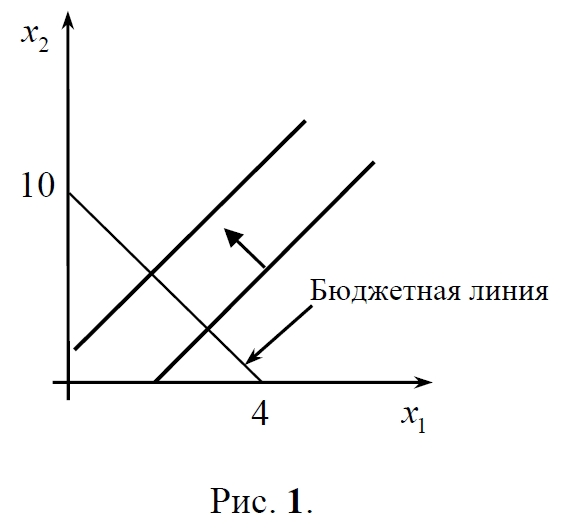

1. Для потребителя блага являются субститутами.
2. Потребитель выберет набор, содержащий 10 единиц второго блага.
3. При некоторых положительных ценах и доходе потребитель может выбрать набор, содержащий оба блага в положительном количестве.

> В тестах 3.11 - 3.13 рассмотрите потребителя с доходом, равным 60 д.е., предпочтения которого представимы функцией полезности $u(x_1,x_2)=\sqrt{x_1x_2}$ . Пусть цена единицы первого блага равна 1 д.е., а второго - 2 д.е.

#### №11

Потребитель выберет набор, содержащий:

1. 20 единиц второго блага;
2. 15 единиц второго блага;
3. 30 единиц второго блага;
4. 15 единиц первого блага;
5. 20 единиц первого блага.

#### №12

Предположим, вводится потоварный налог на первое благо по ставке, равной 2 д.е. В результате введения налога доходы государства от данного потребителя составят:

1. 10
2. 15
3. 20
4. 25
5. 40

#### №13

Предположим теперь, что потоварный налог заменен на паушальный, равный величине дохода государства от потоварного налога, описанного в тесте 3.12. Какое/какие из следующих утверждений верны?

1. Набор, выбранный потребителем при потоварном налоге, стал ему недоступен при паушальном налоге.
2. При паушальном налоге положение потребителя стало лучше, чем при потоварном.
3. При паушальном налоге потребитель увеличил потребление первого блага по сравнению с ситуацией при потоварном налоге.

#### №14

Пусть предпочтения потребителя описываются функцией полезности $u(x_1,x_2)=2\sqrt{x_1}+x_2$ . Известно, что цены благ и доход потребителя таковы, что он потребляет оба блага в положительном количестве. Тогда при получении паушальной субсидии в размере 100 д.е.:

1. объем потребления первого блага возрастет;
2. объем потребления первого блага останется неизменным;
3. объем потребления первого блага снизится;
4. объем потребления второго блага останется неизменным;
5. объем потребления второго блага снизится.

#### №15

Что из нижеперечисленного не может изменить выбор рационального потребителя, предпочтения которого представимы функцией полезности?

1. Умножение функции полезности на отрицательное число.
2. Снижение цены одного из благ в 2 раза.
3. Увеличение всех цен и дохода на 2 д.е.
4. Увеличение дохода в 2 раза.
5. Увеличение всех цен и дохода на 50%.

#### №16

Пусть потребитель не имеет фиксированного дохода но обладает первоначальным запасом благ: 20 единицами первого блага и 30 единицами второго блага. Предположим, цена единицы первого блага составляет 2 д.е., а цена единицы второго блага 4 д.е. Как потребитель изменит объем потребления благ, если запас первого блага возрастет до 30 единиц, а запас второго блага сократится до 25 единиц (считайте, что цены благ остаются неизменными)?

1. Объем потребления обоих благ останется неизменным.
2. Объем потребления первого блага возрастет, а второго – снизится.
3. Объем потребления второго блага возрастет, а первого – снизится.
4. Объем потребления обоих благ возрастет.
5. Объем потребления обоих благ сократится.

#### №17

Рассмотрите потребителя, который не имеет фиксированного дохода, но обладает положительным первоначальным запасом благ. Известно, что предпочтения потребителя монотонны. Предположим, изначально потребитель был чистым покупателем блага, а затем цена этого блага снизилась. Тогда благосостояние потребителя:

1. может как снизиться, так и возрасти;
2. точно не изменится;
3. не снизится;
4. не возрастет;
5. точно снизится.